# EDA buscas

O objeto principal da análise são as buscas e a navegação depois da busca. Criamos esses dados a partir dos dados originais da wikimedia em `/data/search_data.csv`.

Aqui, exploramos esses dados.

```r
library(tidyverse)
library(here)
library(lubridate)
theme_set(theme_bw())
```

```r
buscas = read_csv(here::here("data/search_data.csv"))
glimpse(buscas)
```

```
## Observations: 136,234
## Variables: 9
## $ session_id              <chr> "0000cbcb67c19c45", "0001382e027b2ea4", …
## $ search_index            <dbl> 1, 1, 1, 1, 2, 3, 4, 5, 6, 1, 1, 2, 1, 1…
## $ session_length          <dbl> 0, 303, 435, 58, 58, 58, 58, 58, 58, 0, …
## $ session_start_timestamp <dbl> 2.016030e+13, 2.016031e+13, 2.016031e+13…
## $ session_start_date      <dttm> 2016-03-03 15:20:45, 2016-03-07 08:49:5…
## $ group                   <chr> "b", "b", "b", "a", "a", "a", "a", "a", …
## $ results                 <dbl> 20, 18, 20, 20, 20, 20, 20, 20, 20, 1, 0…
## $ num_clicks              <dbl> 0, 1, 1, 0, 0, 0, 0, 0, 0, 0, 0, 1, 0, 0…
## $ first_click             <dbl> NA, 1, 1, NA, NA, NA, NA, NA, NA, NA, NA…
```

## 1. What is our daily overall clickthrough rate? How does it vary between the groups?

O *clickthrough rate* está definido como a proporção de sessões de buscas em que o usuário clicou em algum dos resultados exibidos. Ou seja, neste ponto considero que é uma relação que envolve a quantidade de sessões que exibiram resultados que foram clicados em relação ao total de sessões. Uma visualização da quantidade de sessões com zero clicks também pode ajudar a na compreensão dos dados.

```r
session_id_clicks <- buscas %>%
    mutate(day_date = floor_date(session_start_date, unit = "day")) %>%
    #filter(day_date != date("2016-03-08")) %>%
    group_by(session_id, day_date, group) %>%
    summarise(nclicks = sum(num_clicks), nsessions = n())
#    glimpse(session_id_clicks)

session_id_clicks2 <- session_id_clicks %>%
    group_by(day_date, group) %>%
    summarise(zero_clicks = sum(nclicks == 0))
glimpse(session_id_clicks2)
```

```
## Observations: 16
## Variables: 3
## Groups: day_date [8]
## $ day_date    <dttm> 2016-03-01, 2016-03-01, 2016-03-02, 2016-03-02, 201…
## $ group       <chr> "a", "b", "a", "b", "a", "b", "a", "b", "a", "b", "a…
## $ zero_clicks <int> 1385, 4343, 1345, 4264, 1362, 4363, 1139, 3822, 967,…
```

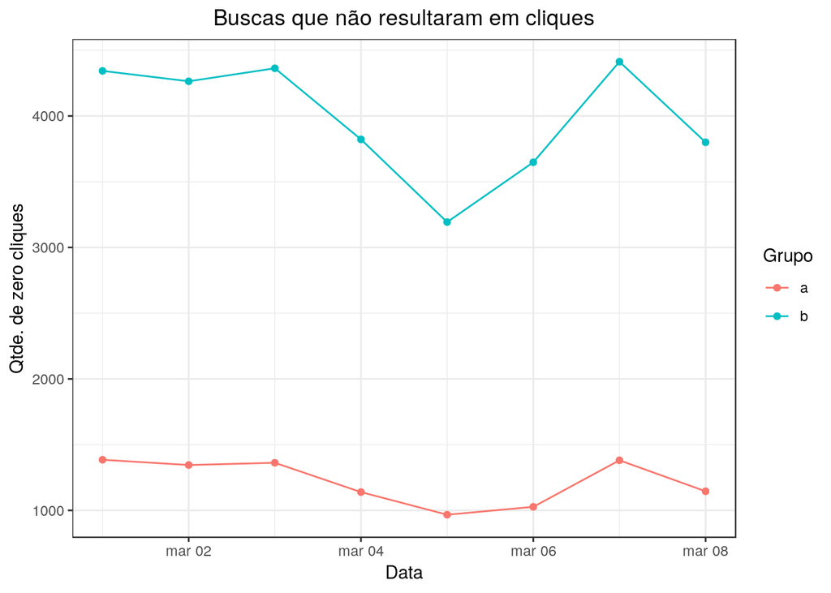

```r
session_id_clicks2 %>%
    #filter(day_date != date("2016-03-08")) %>%
    ggplot(aes(x = day_date, y = zero_clicks, color = group)) +
    geom_point() +
    geom_line() +
    labs(
        title = "Buscas que não resultaram em cliques",
        y = "Qtde. de zero cliques",
        x = "Data",
        color = "Grupo"
    ) +
    theme(plot.title = element_text(hjust = 0.5))
```

É possível ver que o grupo b tem uma quantidade bem maior de buscas e sessões que não resultaram em cliques dos usuários. Desse modo a tendência é que o *clickthrough rate* do grupo b seja menor que o do grupo a.

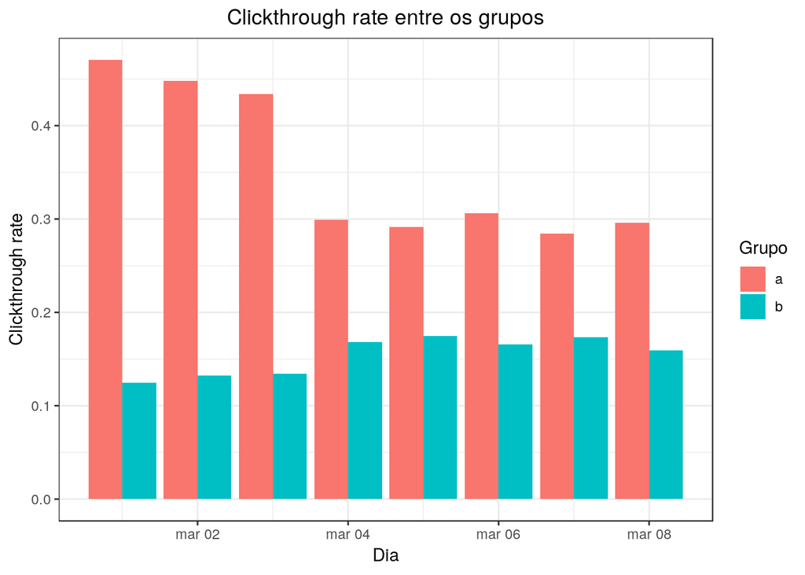

```r
session_id_clicks %>%
    group_by(day_date, group) %>%
    mutate(ctr = sum(nclicks) / sum(nsessions)) %>%
    ggplot() +
    geom_col(aes(x = day_date, y = ctr, fill = group), position = "dodge") +
    labs(
        x = "Dia",
        y = "Clickthrough rate",
        fill = "Grupo",
        title = "Clickthrough rate entre os grupos"
    ) +
    theme(plot.title = element_text(hjust = 0.5))
```

Como esperado, de acordo com observações anteriores, o grupo b tem uma menor proporção de cliques por sessão de buscas, com valores entre 10% e 20%. O grupo a apresenta uma variação maior entre os valores do *clickthrough rate*, mas geralmente em torno de 30% à 40%.

## 2. Which results do people tend to try first? How does it change day-to-day?

Essa pergunta refere-se a que resultado as pessoas normalmente clicam primeiro. Nesse caso é uma relação se a busca retornou resultado, esse resultado gerou um primeiro clique e qual foi a posição do resultado que gerou esse clique. O primeiro passo foi dar uma analisada na variável *first_click*.

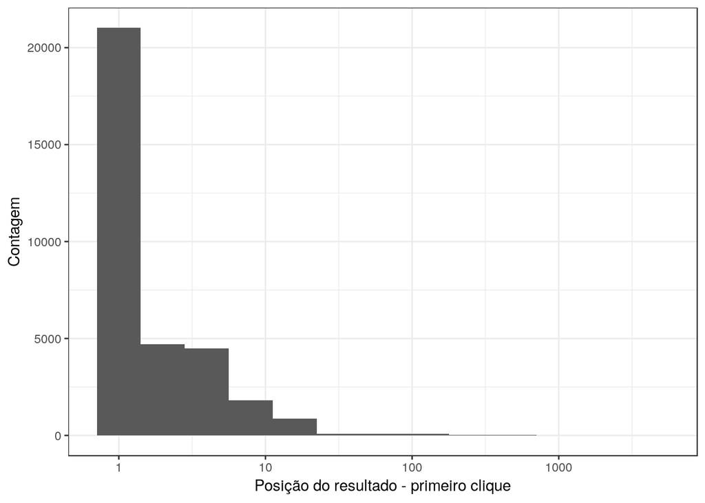

```r
buscas %>%
    filter(!is.na(first_click)) %>%
    ggplot(aes(x = first_click)) +
    geom_histogram(binwidth = .3) +
    scale_x_log10() +
    labs(
        x = "Posição do resultado - primeiro clique",
        y = "Contagem"
    )
```

O histograma mostra uma tendência de clique nos resultados nas primeiras posições da busca.

O próximo passo será a média desses cliques em relação a posição do resultados da busca de acordo com os dias. Nesse caso a dia 08-03-2016 será removido para diminuir seu impacto sobre a média uma vez que nos dados não constam o log desse dia por completo.

```r
click_position <- buscas %>%
    mutate(day_date = floor_date(session_start_date, unit = "day")) %>%
    filter(!is.na(first_click), day_date != date("2016-03-08")) %>%
    group_by(day_date, group) %>%
    summarise(mean_position = mean(first_click), dpc = sd(first_click))
glimpse(click_position)
```

```
## Observations: 14
## Variables: 4
## Groups: day_date [7]
## $ day_date      <dttm> 2016-03-01, 2016-03-01, 2016-03-02, 2016-03-02, 2…
## $ group         <chr> "a", "b", "a", "b", "a", "b", "a", "b", "a", "b", …
## $ mean_position <dbl> 7.997548, 1.832612, 2.660277, 1.922114, 3.336218, …
## $ dpc           <dbl> 147.640984, 2.076076, 8.125653, 2.213418, 11.24327…
```

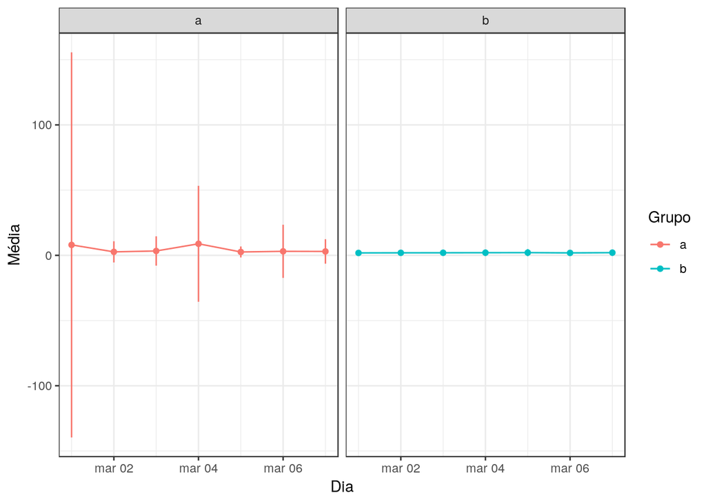

```r
click_position %>%
    ggplot(aes(x = day_date, y = mean_position, color = group)) +
    geom_point() +
    geom_line() +
    geom_errorbar(aes(ymin=mean_position-dpc, ymax=mean_position+dpc), width=.2,
              position=position_dodge(0.05)) +
    facet_wrap(~group) +
    labs(
        x = "Dia",
        y = "Média",
        color = "Grupo"
    )
```

A visualização anterior mostra a média mais o desvio padrão referente a variável *first_click*. Para o grupo A o clique nos primeiros resultados está mostrando picos desvio padrão no primeiro dia, possivelmente sendo causada por valores extremos. O grupo B mantên a tendência de cliques nos primeiros resultados.

## 3. What is our daily overall zero results rate? How does it vary between the groups?

O *zero results rate* é definido como a proporção de buscas que retornaram 0 resultados. Desse modo, antes de visualizar essa proporção, uma visualização dos valores absolutos pode ajudar a ter uma melhor compreensão dessa informação.

```r
zeros = buscas %>% select(results, group, session_start_date) %>% mutate(day_date = date(session_start_date))

zeros_per_week =  zeros %>%  group_by(day_date, group) %>%
    summarise(zeros_results_day = sum(results == 0),
              gt_zero_results = sum(results > 0),
              total_results = n()) %>%
    mutate(proportion = (zeros_results_day/total_results) * 100)

glimpse(zeros_per_week)
```

```
## Observations: 16
## Variables: 6
## Groups: day_date [8]
## $ day_date          <date> 2016-03-01, 2016-03-01, 2016-03-02, 2016-03-0…
## $ group             <chr> "a", "b", "a", "b", "a", "b", "a", "b", "a", "…
## $ zeros_results_day <int> 2350, 1097, 2524, 1065, 2371, 1072, 2068, 947,…
## $ gt_zero_results   <int> 10232, 4695, 10685, 4628, 10909, 4807, 9230, 4…
## $ total_results     <int> 12582, 5792, 13209, 5693, 13280, 5879, 11298, …
## $ proportion        <dbl> 18.67748, 18.93992, 19.10818, 18.70718, 17.853…
```

```r
zeros_per_week %>% distinct(day_date)
```

| day_date |
| --- |
| 2016-03-01 |
| 2016-03-02 |
| 2016-03-03 |
| 2016-03-04 |
| 2016-03-05 |
| 2016-03-06 |
| 2016-03-07 |
| 2016-03-08 |

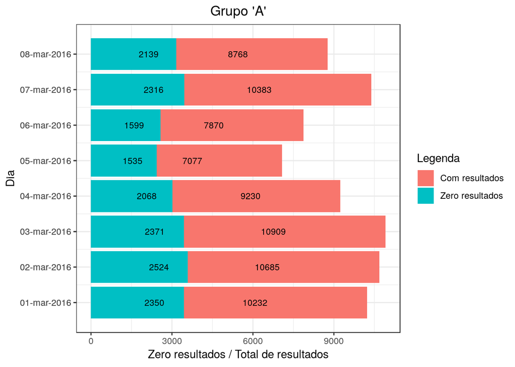

```r
zeros_per_week %>% filter(group == "a") %>%
    ggplot(aes(x = day_date, y = gt_zero_results)) +
    geom_col(mapping = aes(fill = "Com resultados")) +
    geom_text(aes(label = gt_zero_results, y = gt_zero_results),
              size = 3, hjust = 5) +
    geom_col(data = zeros_per_week, mapping = aes(y = zeros_results_day,
                                                  fill = "Zero resultados")) +
    geom_text(aes(label = zeros_results_day, y = zeros_results_day), size = 3) +
    scale_x_date(date_labels = "%d-%b-%Y", breaks = zeros_per_week$day_date) +
    coord_flip() +
    labs(
        title = "Grupo 'A'",
        x = "Dia",
        y = "Zero resultados / Total de resultados",
        fill = "Legenda"
    ) + theme(plot.title = element_text(hjust = 0.5))
```

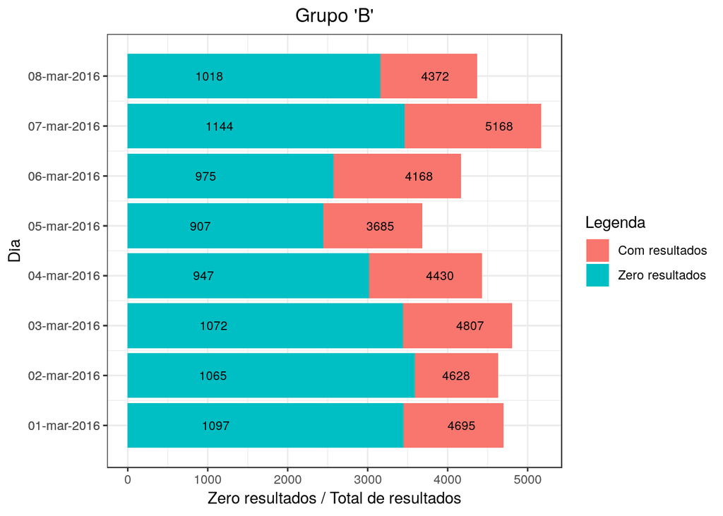

```r
zeros_per_week %>% filter(group == "b") %>%
    ggplot(aes(x = day_date, y = gt_zero_results)) +
    geom_col(mapping = aes(fill = "Com resultados")) +
    geom_text(aes(label = gt_zero_results, y = gt_zero_results),
              size = 3, hjust = 2) +
    geom_col(data = zeros_per_week, mapping = aes(y = zeros_results_day,
                                                  fill = "Zero resultados")) +
    geom_text(aes(label = zeros_results_day, y = zeros_results_day), size = 3) +
    scale_x_date(date_labels = "%d-%b-%Y", breaks = zeros_per_week$day_date) +
    coord_flip() +
    labs(
        title = "Grupo 'B'",
        x = "Dia",
        y = "Zero resultados / Total de resultados",
        fill = "Legenda"
    ) + theme(plot.title = element_text(hjust = 0.5))
```

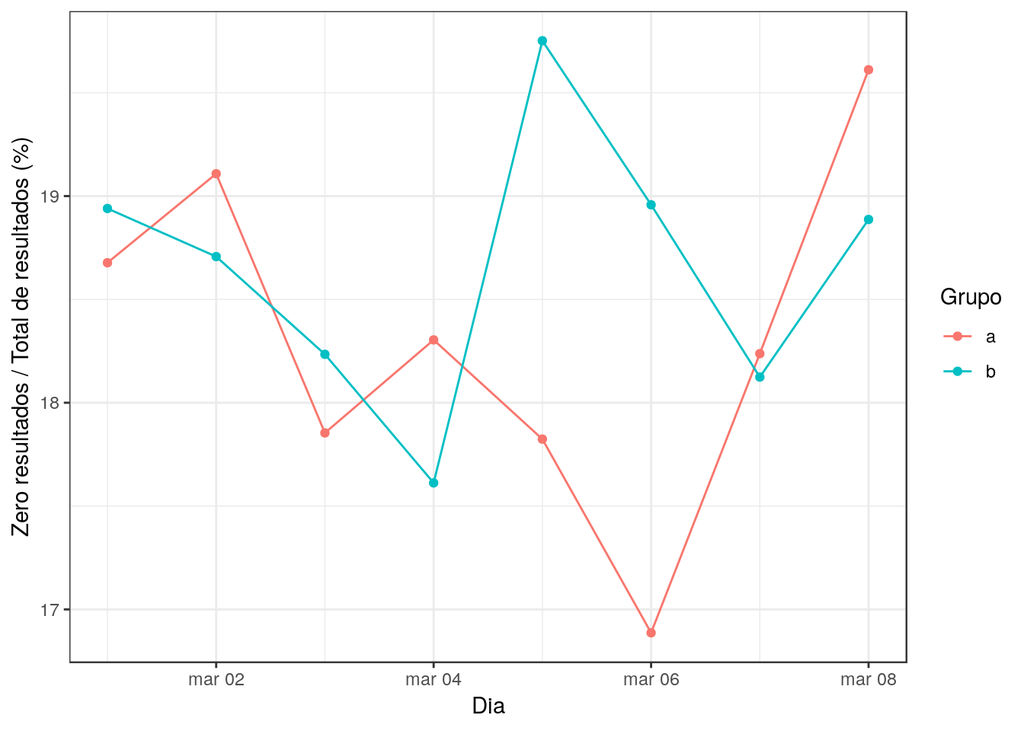

```r
zeros_per_week %>%
    ggplot(aes(x = day_date, y = proportion, color = group)) +
    geom_point() + geom_line() + labs (
        x = "Dia",
        y = "Zero resultados / Total de resultados (%)",
        color = "Grupo"
    )
```

Com exceção dos dias 5 e 6 para o grupo b, que tem um pico de buscas com zero resultados, o gráfico mostra que os dois grupos tem uma proporção parecida nos outros dias.

## 4. Let session length be approximately the time between the first event and the last event in a session. Choose a variable from the dataset and describe its relationship to session length. Visualize the relationship.

Vamos verificar a relação da variável *session_lenght* com a variável *num_clicks*. A ideia é tentar verificar se uma sessão maior significa uma maior quantidade de clicks, por exemplo, o usuário está passando mais tempo na sessão por estar checando os resultados retornados. Ou se mais tempo significa menos clicks, por exemplo, o usuário encontrou o que queria e a sessão está em aberto, porém o usuário está navegando pelas páginas dos resultados encontrados.

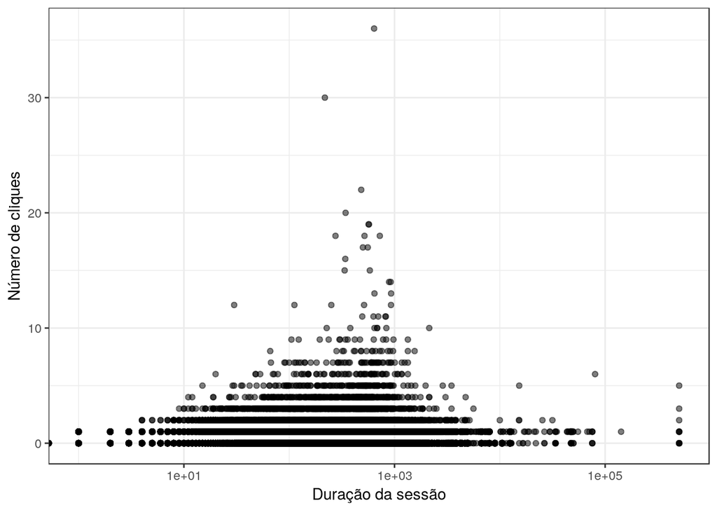

```r
buscas %>%
    arrange(session_length) %>%
    ggplot(aes(x = session_length, y = num_clicks)) +
    geom_point(alpha = .5) +
    scale_x_log10() +
    labs(
        x = "Duração da sessão",
        y = "Número de cliques"
    )
```

Um scatterplot simples mostra que algumas coisas precisam ser consideradas, por exemplo, existem sessões que estão durando vários dias assim como sessões que estão durando 0 segundos. Dessa forma serão removidas as sessões que tenha uma duração maior do que 24h e também duração igual a 0 segundos. Inicialmente consideraremos a média de cliques por duração da sessão.

```r
duration_n_clicks <- buscas %>%
    group_by(session_length) %>%
    summarise(mclicks = mean(num_clicks), sessions = n())

glimpse(duration_n_clicks)
```

```
## Observations: 1,577
## Variables: 3
## $ session_length <dbl> 0, 1, 2, 3, 4, 5, 6, 7, 8, 9, 10, 11, 12, 13, 14,…
## $ mclicks        <dbl> 0.0000000, 0.3907285, 0.3821138, 0.2931416, 0.234…
## $ sessions       <int> 27611, 151, 615, 904, 912, 959, 864, 868, 837, 88…
```

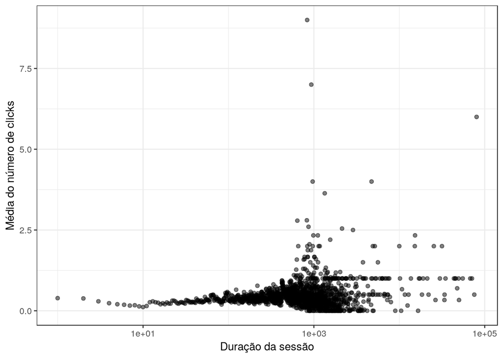

```r
duration_n_clicks %>%
    filter(session_length > 0, session_length < 86400) %>%
    ggplot(aes(x = session_length, y = mclicks)) +
    geom_point(alpha = .5) +
    scale_x_log10() +
    labs(
        x = "Duração da sessão",
        y = "Média do número de clicks"
    )
```

Aparentemente não existe uma relação que afirme que quanto maior o tempo da sessão maior a quantidade de cliques que ela pode gerar.

Testando os coeficientes de correlação entre as variáveis:

```r
duration_n_clicks %>%
    summarise(pearson = cor(session_length, mclicks, method = "pearson"),
                spearman = cor(session_length, mclicks, method = "spearman"),
                kendall = cor(session_length, mclicks, method = "kendall"))
```

| pearson | spearman | kendall |
| --- | --- | --- |
| 0.1195386 | 0.01322297 | 0.01827402 |

Os resultados confirmam o que foi visto nos gráficos. Os testes mostram que existe uma correlação muito fraca entre a duração da sessão e a quantidade de cliques geradas por ela.

Testando então a relação de session_lenght com outra variável. Verificando se existe alguma tendência de duração das sessões entre os diferentes grupos. Nessa caso estamos verificando a relação da variável *session_lenght* com a variável *group*.

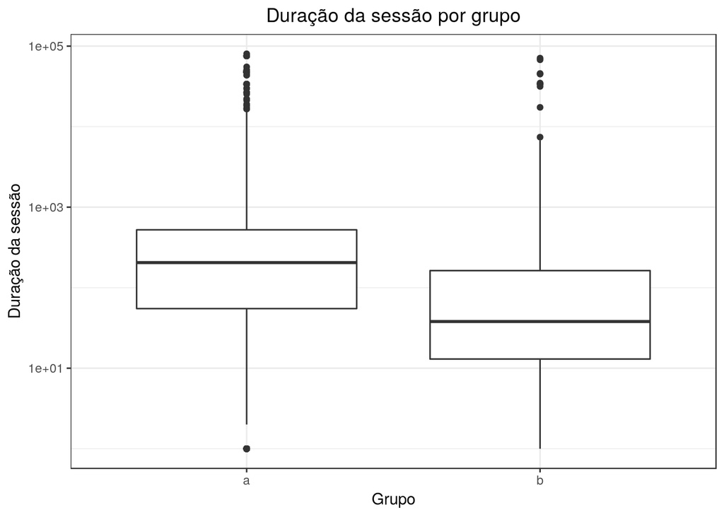

```r
buscas %>%
    filter(session_length > 0, session_length < 86400) %>%
    ggplot(aes(y = session_length, x = group)) +
    geom_boxplot() +
    scale_y_log10() +
    labs(
        x = "Grupo",
        y = "Duração da sessão",
        title = "Duração da sessão por grupo"
    ) +
    theme(plot.title = element_text(hjust = 0.5))
```

Aparentemente existe uma tendência do grupo a a ter sessões com durações maiores, vendo que os 50% dos valores mais prováveis do grupo A estão acima da mediana do grupo B . Vale lembrar que a amostra do grupo A é maior que a do grupo B.

Uma ideia para uma futura análise seria a de buscas, cliques e primeiros cliques do grupo B comparados com os do grupo A pra verificas se pra confirmar se as sessões do grupo B mesmo sendo em sua maioria menores estão gerando mais cliques que as sessões de A.